# SPE git - quick start

Damien G.

2 May 2018

This document is a quick uide to clone/pull the latest version of [SPE repository](https://github.com/SPE-R/SPE). For ease of use, I will use [GitKraken](https://www.gitkraken.com/) software in this document.

# Prerequest

- having [GitKraken](https://www.gitkraken.com) installed on your machine. ([How to Install GitKraken](https://support.gitkraken.com/how-to-install%5D))
- having a [github](https://github.com/) account and being a member of SPE-R organization ([list of SPE-R members](https://github.com/orgs/SPE-R/people))

# Linking GitKraken to your github account

1. Open `GitKraken` software
2. If this is the firs time you open the software, you will be asked to give some git ids. Click on **Sign in with GitHub** and enter your [github](https://github.com/) credential.

[figure not shown]

Once you have done it once you should be automatically connected connected to your git account each time you will open `GitKraken`. You should easily check it in the upper right corner of `GitKraken` window.

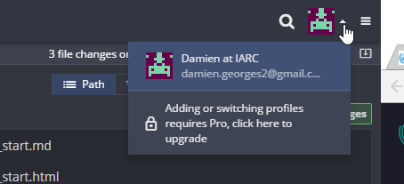

# Cloning [SPE repository](https://github.com/SPE-R/SPE)

You only have to do it once. If you have already done that you can go to the next step .

1. Click on the top left corner (folder)
2. Click on `Clone`
3. Select `Github.com`
4. Click on `Browse` and define where you want the repository to be clone on your local machine
5. Scroll down until you find `SPE-R` > `SPE`
6. Click on `Clone the repo!`

[figure not shown]

# Opening [SPE repository](https://github.com/SPE-R/SPE)

1. Click on the top left corner (folder)
2. Click on `Open`
3. Select `Recently Openned`
4. Select `SPE`

If `SPE` does not show up in the recently opened projects, click on `Open a Repository` and select the directory where hou have clone [SPE repository](https://github.com/SPE-R/SPE) (directory named `SPE`)

[figure not shown]

# Pulling online version of the repository

Please mind to do it everytime you open the repository.

1. Just clivk on `Pull` button

[figure not shown]

2. Be sure that a message like `Pulled Successfully` shows up on the top right corner

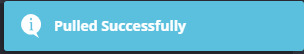